# Introduction

## The tmdb movie dataset description.

This report is aimed at performing data analysis on tmdb movie data set. This dataset contains 10000 movies with different informations.wa are going to analyse this dataset using numpy,pandas,and matplotlib and seaborn libraries.One or more questions will be asked and answered based on some of the attributes provided by this dataset include cast,genre, runtime, popularity,ratings, revenue, budget and so on.Below are the question to be answered by the information produced about this dataset.

## Questions

1. Which genre and production company has the most movie produced and most popularity from the 1960 to 2015.
2. What is the average budget spent,revenue generated and profit made by each genres of movies over the years.
3. Which genre are the highest in terms of budget,profit and revenue and popularity for each year from 1960 to 2015.
4. what is relationship between revenue,profit and popularity and the relationship between runtime, revenue and budget.

# ASSESSING THE DATASET

```python
import pandas as pd
import numpy as np
import matplotlib.pyplot as plt
import seaborn as sns
%matplotlib inline
plt.style.use('seaborn')

df = pd.read_csv('tmdb-movies.csv')
df.head(3)
```

|  | id | imdb_id | popularity | budget | revenue | original_title | cast | homepage | director | tagline | ... | overview | runtime | genres | production_companies | release_date | vote_count | vote_average | release_year | budget_adj | revenue_adj |
| --- | --- | --- | --- | --- | --- | --- | --- | --- | --- | --- | --- | --- | --- | --- | --- | --- | --- | --- | --- | --- | --- |
| 0 | 135397 | tt0369610 | 32.985763 | 150000000 | 1513528810 | Jurassic World | Chris Pratt\|Bryce Dallas Howard\|Irrfan Khan\|Vi... | http://www.jurassicworld.com/ | Colin Trevorrow | The park is open. | ... | Twenty-two years after the events of Jurassic ... | 124 | Action\|Adventure\|Science Fiction\|Thriller | Universal Studios\|Amblin Entertainment\|Legenda... | 6/9/15 | 5562 | 6.5 | 2015 | 1.379999e+08 | 1.392446e+09 |
| 1 | 76341 | tt1392190 | 28.419936 | 150000000 | 378436354 | Mad Max: Fury Road | Tom Hardy\|Charlize Theron\|Hugh Keays-Byrne\|Nic... | http://www.madmaxmovie.com/ | George Miller | What a Lovely Day. | ... | An apocalyptic story set in the furthest reach... | 120 | Action\|Adventure\|Science Fiction\|Thriller | Village Roadshow Pictures\|Kennedy Miller Produ... | 5/13/15 | 6185 | 7.1 | 2015 | 1.379999e+08 | 3.481613e+08 |
| 2 | 262500 | tt2908446 | 13.112507 | 110000000 | 295238201 | Insurgent | Shailene Woodley\|Theo James\|Kate Winslet\|Ansel... | http://www.thedivergentseries.movie/#insurgent | Robert Schwentke | One Choice Can Destroy You | ... | Beatrice Prior must confront her inner demons ... | 119 | Adventure\|Science Fiction\|Thriller | Summit Entertainment\|Mandeville Films\|Red Wago... | 3/18/15 | 2480 | 6.3 | 2015 | 1.012000e+08 | 2.716190e+08 |

3 rows × 21 columns

```python
# To display a concise summary of the dataframe
#with the number of non-null values in each column
df.info()
df.columns
```

```
<class 'pandas.core.frame.DataFrame'>
RangeIndex: 10866 entries, 0 to 10865
Data columns (total 21 columns):
 #   Column                Non-Null Count  Dtype
---  ------                --------------  -----
 0   id                    10866 non-null  int64
 1   imdb_id               10856 non-null  object
 2   popularity            10866 non-null  float64
 3   budget                10866 non-null  int64
 4   revenue               10866 non-null  int64
 5   original_title        10866 non-null  object
 6   cast                  10790 non-null  object
 7   homepage              2936 non-null   object
 8   director              10822 non-null  object
 9   tagline               8042 non-null   object
 10  keywords              9373 non-null   object
 11  overview              10862 non-null  object
 12  runtime               10866 non-null  int64
 13  genres                10843 non-null  object
 14  production_companies  9836 non-null   object
 15  release_date          10866 non-null  object
 16  vote_count            10866 non-null  int64
 17  vote_average          10866 non-null  float64
 18  release_year          10866 non-null  int64
 19  budget_adj            10866 non-null  float64
 20  revenue_adj           10866 non-null  float64
dtypes: float64(4), int64(6), object(11)
memory usage: 1.7+ MB
```

```
Index(['id', 'imdb_id', 'popularity', 'budget', 'revenue', 'original_title',
       'cast', 'homepage', 'director', 'tagline', 'keywords', 'overview',
       'runtime', 'genres', 'production_companies', 'release_date',
       'vote_count', 'vote_average', 'release_year', 'budget_adj',
       'revenue_adj'],
      dtype='object')
```

```python
df.shape
#to return a tuple of the no of rows and column of the dataframe
```

```
(10866, 21)
```

```python
df.isnull().sum()
```

```
id                         0
imdb_id                   10
popularity                 0
budget                     0
revenue                    0
original_title             0
cast                      76
homepage                7930
director                  44
tagline                 2824
keywords                1493
overview                   4
runtime                    0
genres                    23
production_companies    1030
release_date               0
vote_count                 0
vote_average               0
release_year               0
budget_adj                 0
revenue_adj                0
dtype: int64
```

```python
#To get the number of unique values in each column
df.nunique()
```

```
id                      10865
imdb_id                 10855
popularity              10814
budget                    557
revenue                  4702
original_title          10571
cast                    10719
homepage                 2896
director                 5067
tagline                  7997
keywords                 8804
overview                10847
runtime                   247
genres                   2039
production_companies     7445
release_date             5909
vote_count               1289
vote_average               72
release_year               56
budget_adj               2614
revenue_adj              4840
dtype: int64
```

```python
#to get descriptive statistics about each column in the dataset
df.describe()
```

|  | id | popularity | budget | revenue | runtime | vote_count | vote_average | release_year | budget_adj | revenue_adj |
| --- | --- | --- | --- | --- | --- | --- | --- | --- | --- | --- |
| count | 10866.000000 | 10866.000000 | 1.086600e+04 | 1.086600e+04 | 10866.000000 | 10866.000000 | 10866.000000 | 10866.000000 | 1.086600e+04 | 1.086600e+04 |
| mean | 66064.177434 | 0.646441 | 1.462570e+07 | 3.982332e+07 | 102.070863 | 217.389748 | 5.974922 | 2001.322658 | 1.755104e+07 | 5.136436e+07 |
| std | 92130.136561 | 1.000185 | 3.091321e+07 | 1.170035e+08 | 31.381405 | 575.619058 | 0.935142 | 12.812941 | 3.430616e+07 | 1.446325e+08 |
| min | 5.000000 | 0.000065 | 0.000000e+00 | 0.000000e+00 | 0.000000 | 10.000000 | 1.500000 | 1960.000000 | 0.000000e+00 | 0.000000e+00 |
| 25% | 10596.250000 | 0.207583 | 0.000000e+00 | 0.000000e+00 | 90.000000 | 17.000000 | 5.400000 | 1995.000000 | 0.000000e+00 | 0.000000e+00 |
| 50% | 20669.000000 | 0.383856 | 0.000000e+00 | 0.000000e+00 | 99.000000 | 38.000000 | 6.000000 | 2006.000000 | 0.000000e+00 | 0.000000e+00 |
| 75% | 75610.000000 | 0.713817 | 1.500000e+07 | 2.400000e+07 | 111.000000 | 145.750000 | 6.600000 | 2011.000000 | 2.085325e+07 | 3.369710e+07 |
| max | 417859.000000 | 32.985763 | 4.250000e+08 | 2.781506e+09 | 900.000000 | 9767.000000 | 9.200000 | 2015.000000 | 4.250000e+08 | 2.827124e+09 |

```python
df.duplicated().sum() # to get the total number of duplicated rows
```

```
1
```

from the assessing infomation about this data set. it can be noted that a. this data set has 10866 rows and and 21 columns b. some of the rows are not relevant in answering the questions we have posed. there is a duplicate data c. the release_date has a wrong data type. d. the minimum value from the description of the dataset show that revenue,budget and runtime all have 0 as their values which is invalid. e. some columns hava data seperated by the | sign.

### CLEANING THE DATA

###### we are going to drop the rows that are irrelevant in answering our questions

```python
irr_columns = ['imdb_id','cast','homepage','tagline','overview', 'vote_count', 'vote_average','budget_adj','revenue_adj','keywords']# list of columns that are irrrelevant to our analysis.
df.drop(irr_columns, axis = 1, inplace = True)
```

```python
#now let us check the shape of the new dataset
df.shape
```

```
(10866, 11)
```

### deduping the dataset

```python
#drop duplicates data
df.drop_duplicates(inplace = True)
df.shape
```

```
(10865, 11)
```

###### changing the datatypes.

```python
df.release_date = pd.to_datetime(df.release_date)
df.dtypes
```

```
id                               int64
popularity                     float64
budget                           int64
revenue                          int64
original_title                  object
director                        object
runtime                          int64
genres                          object
production_companies            object
release_date            datetime64[ns]
release_year                     int64
dtype: object
```

```python
df[df['revenue']==0].count()
```

```
id                      6016
popularity              6016
budget                  6016
revenue                 6016
original_title          6016
director                5973
runtime                 6016
genres                  5993
production_companies    5082
release_date            6016
release_year            6016
dtype: int64
```

```python
#df.iloc[:,np.r_[2:4,6]] = df.iloc[:,np.r_[2:4,6]].replace(0,np.NAN)


c = df.revenue.mean()
d = df.budget.mean()
e = df.runtime.mean()

df.revenue.replace(0,c)
df.budget.replace(0,d)
df.runtime.replace(0,e)
```

```
0        124.0
1        120.0
2        119.0
3        136.0
4        137.0
         ...
10861     95.0
10862    176.0
10863     94.0
10864     80.0
10865     74.0
Name: runtime, Length: 10865, dtype: float64
```

```python
df.info()
```

```
<class 'pandas.core.frame.DataFrame'>
Int64Index: 10865 entries, 0 to 10865
Data columns (total 11 columns):
 #   Column                Non-Null Count  Dtype
---  ------                --------------  -----
 0   id                    10865 non-null  int64
 1   popularity            10865 non-null  float64
 2   budget                10865 non-null  int64
 3   revenue               10865 non-null  int64
 4   original_title        10865 non-null  object
 5   director              10821 non-null  object
 6   runtime               10865 non-null  int64
 7   genres                10842 non-null  object
 8   production_companies  9835 non-null   object
 9   release_date          10865 non-null  datetime64[ns]
 10  release_year          10865 non-null  int64
dtypes: datetime64[ns](1), float64(1), int64(5), object(4)
memory usage: 1018.6+ KB
```

```python
#let us drop the new null values.
df.dropna(inplace=True)
df.shape
```

```
(9806, 11)
```

Since we will be dealing with the profit made from each movie lets create a profit column

```python
df['profit'] = df['revenue'] - df['budget']
df.shape
```

```
(9806, 12)
```

```python
df.describe()
```

|  | id | popularity | budget | revenue | runtime | release_year | profit |
| --- | --- | --- | --- | --- | --- | --- | --- |
| count | 9806.000000 | 9806.000000 | 9.806000e+03 | 9.806000e+03 | 9806.000000 | 9806.000000 | 9.806000e+03 |
| mean | 63287.653783 | 0.693143 | 1.612525e+07 | 4.407785e+07 | 102.744340 | 2000.890271 | 2.795260e+07 |
| std | 90808.473021 | 1.035525 | 3.216819e+07 | 1.224038e+08 | 28.134561 | 13.032372 | 1.012824e+08 |
| min | 5.000000 | 0.000188 | 0.000000e+00 | 0.000000e+00 | 0.000000 | 1960.000000 | -4.139124e+08 |
| 25% | 10247.500000 | 0.231581 | 0.000000e+00 | 0.000000e+00 | 90.000000 | 1994.000000 | 0.000000e+00 |
| 50% | 18725.500000 | 0.418756 | 1.403930e+05 | 0.000000e+00 | 100.000000 | 2005.000000 | 0.000000e+00 |
| 75% | 70586.750000 | 0.774231 | 1.900000e+07 | 3.064621e+07 | 112.000000 | 2011.000000 | 1.409774e+07 |
| max | 417859.000000 | 32.985763 | 4.250000e+08 | 2.781506e+09 | 877.000000 | 2015.000000 | 2.544506e+09 |

```python
df.head(3)
```

|  | id | popularity | budget | revenue | original_title | director | runtime | genres | production_companies | release_date | release_year | profit |
| --- | --- | --- | --- | --- | --- | --- | --- | --- | --- | --- | --- | --- |
| 0 | 135397 | 32.985763 | 150000000 | 1513528810 | Jurassic World | Colin Trevorrow | 124 | Action\|Adventure\|Science Fiction\|Thriller | Universal Studios\|Amblin Entertainment\|Legenda... | 2015-06-09 | 2015 | 1363528810 |
| 1 | 76341 | 28.419936 | 150000000 | 378436354 | Mad Max: Fury Road | George Miller | 120 | Action\|Adventure\|Science Fiction\|Thriller | Village Roadshow Pictures\|Kennedy Miller Produ... | 2015-05-13 | 2015 | 228436354 |
| 2 | 262500 | 13.112507 | 110000000 | 295238201 | Insurgent | Robert Schwentke | 119 | Adventure\|Science Fiction\|Thriller | Summit Entertainment\|Mandeville Films\|Red Wago... | 2015-03-18 | 2015 | 185238201 |

After dropping the unused columns and rows with null data we now have a cleaned dataset with 9806 rows and 12 colums which sufficient to carry out our analysis.

```python
#now let save our new dataset
df.to_csv('movie_undroped_cleaned.csv', index = False)
```

```python
import pandas as pd
import numpy as np
import matplotlib.pyplot as plt
import seaborn as sns
%matplotlib inline
plt.style.use('seaborn')

dfm =pd.read_csv('movie_undroped_cleaned.csv')
dfp = dfm.copy()
dfm.columns
```

```
Index(['id', 'popularity', 'budget', 'revenue', 'original_title', 'director',
       'runtime', 'genres', 'production_companies', 'release_date',
       'release_year', 'profit'],
      dtype='object')
```

```python
def get_list(col_name):
    """
    Parameters
    ----------
    col_name : column

    Return
    ----------
    a list of unique values in the column.

    """
    unique = list(dfm[col_name].unique())
    unique_list =[] #empty list to contain unique genres in the genres colums
    for j in range(len(unique)):
        y= unique[j]
        z= y.split('|')
        for text in range(len(z)):
            if z[text] not in unique_list:
                unique_list.append(z[text])
    return unique_list
```

```python
dfm['genres']= dfm['genres'].apply(lambda x: x.split('|'))
dfm['production_companies'] = dfm['production_companies'].apply(lambda x: x.split('|'))
```

```python
dfm.head()
```

|  | id | popularity | budget | revenue | original_title | director | runtime | genres | production_companies | release_date | release_year | profit |
| --- | --- | --- | --- | --- | --- | --- | --- | --- | --- | --- | --- | --- |
| 0 | 135397 | 32.985763 | 150000000 | 1513528810 | Jurassic World | Colin Trevorrow | 124 | [Action, Adventure, Science Fiction, Thriller] | [Universal Studios, Amblin Entertainment, Lege... | 2015-06-09 | 2015 | 1363528810 |
| 1 | 76341 | 28.419936 | 150000000 | 378436354 | Mad Max: Fury Road | George Miller | 120 | [Action, Adventure, Science Fiction, Thriller] | [Village Roadshow Pictures, Kennedy Miller Pro... | 2015-05-13 | 2015 | 228436354 |
| 2 | 262500 | 13.112507 | 110000000 | 295238201 | Insurgent | Robert Schwentke | 119 | [Adventure, Science Fiction, Thriller] | [Summit Entertainment, Mandeville Films, Red W... | 2015-03-18 | 2015 | 185238201 |
| 3 | 140607 | 11.173104 | 200000000 | 2068178225 | Star Wars: The Force Awakens | J.J. Abrams | 136 | [Action, Adventure, Science Fiction, Fantasy] | [Lucasfilm, Truenorth Productions, Bad Robot] | 2015-12-15 | 2015 | 1868178225 |
| 4 | 168259 | 9.335014 | 190000000 | 1506249360 | Furious 7 | James Wan | 137 | [Action, Crime, Thriller] | [Universal Pictures, Original Film, Media Righ... | 2015-04-01 | 2015 | 1316249360 |

```python
df_exploded = dfm.explode('genres')
```

#### Question 1 : Which genre and production company has the most movie produced and most popularity from the 1960 to 2015.

```python
def most_freq(col_name):
    """
    Parameters
    ----------
    col_name : the column we want to get.

    Returns
    -------
    unique_list : A list of unque element in the column in term of their fequency.

    """
     # to split the column and the add all the values in the genres
     #colum to find the unique elements in the list and
     #the number of time the occur using value_counts
    unique_list = pd.Series(dfp[col_name].str.cat(
        sep='|').split('|')).value_counts()
    return unique_list
```

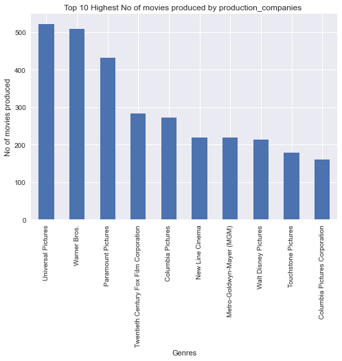

```python
#to get the 10 production company with the most movies prduced
most_freq('production_companies')[:10].plot(kind = 'bar',
                        title= 'Top 10 Highest No of movies produced by production_companies ');
plt.xlabel('Genres')
plt.ylabel('No of movies produced');
```

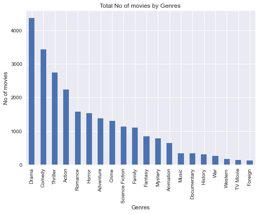

```python
most_freq('genres')[:].plot(kind = 'bar',
    title= 'Total No of movies by Genres ');
plt.xlabel('Genres')
plt.ylabel('No of movies');
```

from this we can see that drama is the most frequent genre, followed by comedy and then thriller

##### most popular genre,production companies

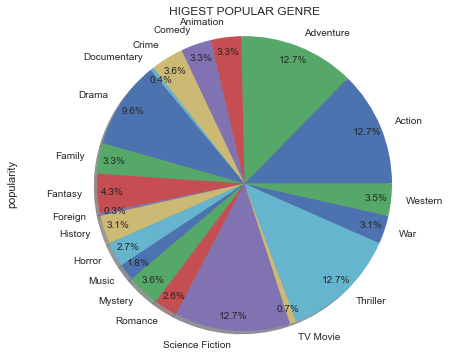

```python
#most_popular_genre
popular = df_exploded.groupby('genres').max()['popularity']

popular.plot(kind ='pie', figsize= (8,6), title = 'Higest Popular Genre'.upper() ,
             autopct='%1.1f%%', shadow=True, startangle=0, pctdistance=0.9);
plt.axis('equal');
```

WE can see from the pie chart above that the movie with the most popularity is of 4 genres which are Adventure,Action ,Science Fiction and Thriller which can also be seen from the barchart below

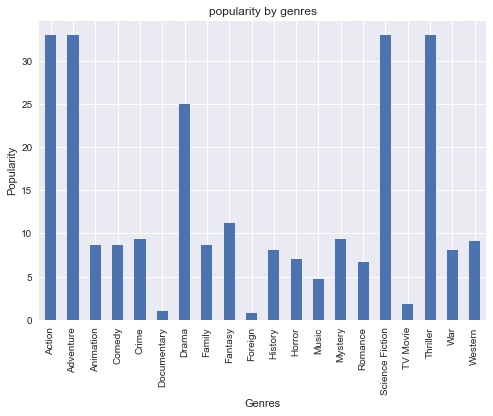

```python
c = df_exploded.groupby('genres').max()['popularity' ]
c.plot(kind='bar', title = 'popularity by genres');
plt.xlabel('Genres')
plt.ylabel('Popularity');
```

##### most popular production companies of all time

```python
#to split the data in the production_companies
#column to individual row
df_exploded_pro= dfm.explode('production_companies')
```

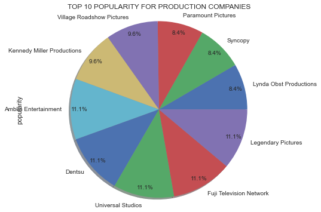

```python
#to get the production company that has produced the
#movies with the highest popularity
popular = df_exploded_pro.groupby('production_companies')['popularity'].max()
top_10 = popular.sort_values()[-10:]

top_10.plot(kind ='pie', figsize= (8,6), title = 'Top 10 popularity for production companies'.upper() ,
             autopct='%1.1f%%', shadow=True, startangle=0, pctdistance=0.9);
plt.axis('equal');
```

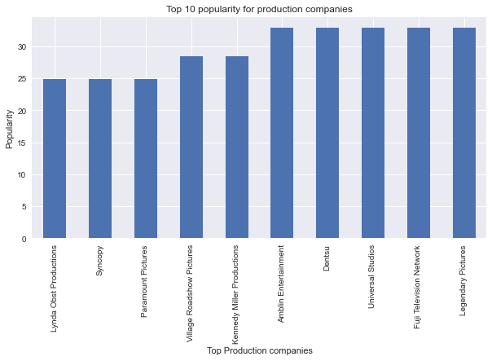

```python
top_10.plot(kind ='bar', figsize= (10,5),
       title = 'Top 10 popularity for production companies');
plt.xlabel('Top Production companies')
plt.ylabel('Popularity');
```

#### Question 2: What is the average budget spent,revenue generated and profit made by each genres of movies over the years.

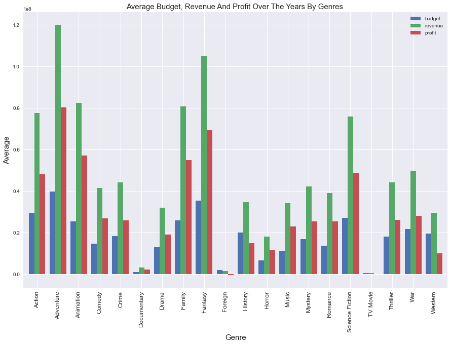

```python
def gen_rev(col_name):
    '''this is to get the revenue,profit and budget
    for each genres over time'''
    return df_exploded.groupby(['genres'], as_index=False)[col_name].mean()

#gen_rev('profit')
width = 0.35
c= gen_rev('profit')
d= c.merge(gen_rev('revenue'))
e= d.merge(gen_rev('budget'))


e.plot(x="genres", y=["budget", "revenue", "profit"],
       kind="bar", width = 0.8, figsize = (15,10));
plt.title('Average budget, revenue and profit over the years by genres '.title(),
         fontsize=15)
plt.xlabel('Genre', fontsize=15)
plt.ylabel('Average', fontsize=15);
plt.xticks( fontsize=12);
```

### QUESTION 3: Which genre are the highest in terms of budget,profit and revenue and popularity from year to year

To Answer this we define a function that groups our data by release year so we can get any of the columns we want.

```python
def per_year(stat, col):
    """
    Parameters
    ----------
    stat : statistics to be
    perform by the agg function(either max or sum).
    sort_col : column we want to get for each year.

    Returns
    ----------
    A barchart with most sort_col for each year

    """
    per_year = df_exploded[['release_year', col, 'genres', ]].sort_values(['release_year', col],
                                                                               ascending=False)
    # to get the best profit for each year after grouping by release year
    per_year = pd.DataFrame(per_year.groupby(['release_year'], as_index=False).agg({col: [stat],
                                                                                    'genres': ['first']}))

    # The next three lines are to get the list of value in each of the three columns
    v = [i for i in per_year.iloc[:, 0]]
    w = [i for i in per_year.iloc[:, 1]]
    x = [i for i in per_year.iloc[:, -1]]

    # to crate a new dataframe from the per_year dataframe
    #so that no column with be multindexed.
    df_new = pd.DataFrame({'year': v, col: w, 'genres': x})
    print(df_new.genres.value_counts())
    #to plot barchart using matplotlib pyplot
    fig, ax = plt.subplots(figsize=(12, 7) )
    hbars = ax.bar(df_new.year, df_new[col], align='center',width =0.5)
    ax.bar_label(hbars, labels=df_new.genres,
                 rotation=90, padding=10, fontsize=12.5)
    ax.set_title(f' Genre with the most {col} for each year'.title())
    ax.set_xlabel('year'.title(), fontsize=15)
    ax.set_ylabel(col.title(), fontsize=15)
    # To setup the figure size.
    sns.set(rc={'figure.figsize':(10,5)})
    sns.set_style("darkgrid")
```

#### A. Genre with the most budget from year to year

```
Action             18
Adventure          16
Drama               8
History             3
Comedy              3
Music               2
Science Fiction     2
Animation           2
Fantasy             1
Family              1
Name: genres, dtype: int64
```

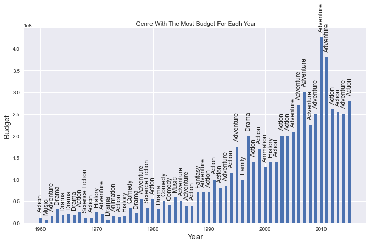

```python
per_year(max,'budget')
```

from the graph it can be seen that Action and Adventure movie genres require relatively high budget per year as they occur more than than the others on the barchart

#### B. genre with the most revenue from year to year

```
Adventure          24
Drama              10
Action              8
Science Fiction     3
Animation           3
Family              2
Horror              2
History             1
Comedy              1
Fantasy             1
Crime               1
Name: genres, dtype: int64
```

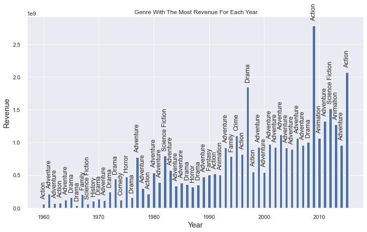

```python
per_year(max, 'revenue')
```

from the graph it can be seen that Adventure movie genre generates relatively more revenue per year as they occur more than than the others on the barchart from 1960-2015.

#### C. genre with the most profit from year to year

```
Adventure          24
Drama              11
Action              7
Science Fiction     3
Animation           3
Family              2
Horror              2
History             1
Comedy              1
Fantasy             1
Crime               1
Name: genres, dtype: int64
```

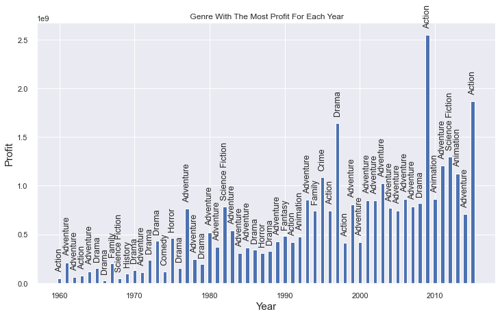

```python
per_year(max, 'profit')
```

Also from this chart the genres with the most profit are Adventure in 24 different years, followed by Drama and Action genres respectively over the years.

#### D. genre with the most popularity from year to year

```
Adventure          17
Action             10
Drama               7
Animation           5
Science Fiction     5
Crime               3
Horror              2
Romance             2
Family              1
Music               1
Thriller            1
Comedy              1
Fantasy             1
Name: genres, dtype: int64
```

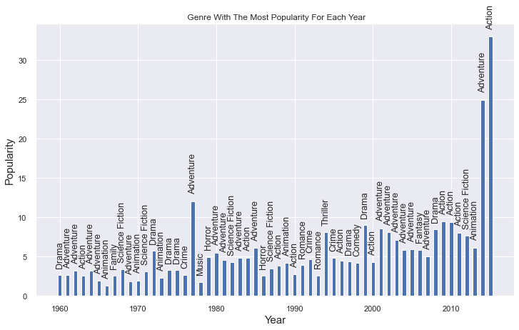

```python
per_year(max, 'popularity')
```

For 17 diffenrent years Adventure ids the most genre released. we can see that Adventure genre is very popular in the early 2000s from the bar chart.

### Question 4: relationship between revenue,profit and popularity and relationship between runtime, revenue and budget.

we are going to use framework of linear regression statistical models to estimate a simple relationship between these movie attributes using the seaborn Regplot..

```python
def plot_rel(col_a,col_b) :
    """
    Parameters
    ----------
    col_a: first column
    col_b : second column.

    Returns
    ----------
    A scatter chart showing the correlation between col_a and col_b

    """

    import statsmodels.api as sn
    import scipy
    #To get the statistacal correlation tbetween the two columns
    print(f'correlation between {col_a} and {col_b} is' , scipy.stats.pearsonr(df[col_a],df[col_b])[0])
    sns.set_theme(color_codes=True)
    #To plot a scatter chart
    sns.regplot(x=col_a, y= col_b, data=dfp, marker="+",
                scatter_kws={"s": 50 });
    sns.set(rc={'figure.figsize':(7,5)})
    plt.xlabel(col_a.title(), fontsize=12)
    plt.ylabel(col_b.title(), fontsize=12);
    plt.title(f'relationship between {col_a} and {col_b}'.title(), fontsize=12);

    #print('correlation between col_a and col_b is' , scipy.stats.pearsonr(df[col_a],df[col_b])[0])
```

```
correlation between popularity and profit is 0.629455261157025
PLOT 1
```

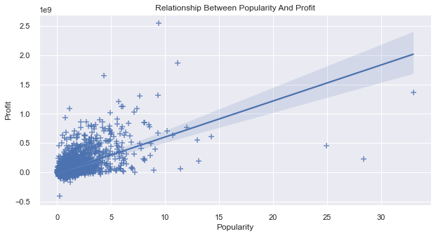

```python
plot_rel("popularity","profit")
print('PLOT 1')
print('\n')
```

```
correlation between popularity and revenue is 0.662552879591694
PLOT 2
```

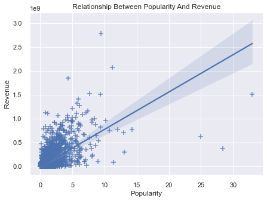

```python
plot_rel("popularity","revenue")
print('PLOT 2')
print('\n')
```

```
correlation between runtime and budget is 0.21510912662119042
PLOT 3
```

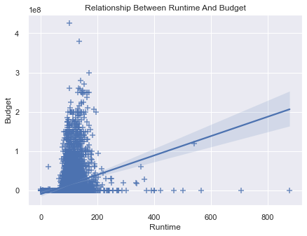

```python
plot_rel("runtime","budget")
print('PLOT 3')
print('\n')
```

```
correlation between budget and revenue is 0.7313444851216069
PLOT 4
```

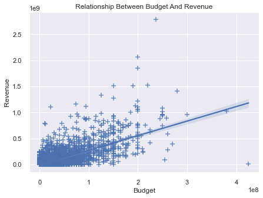

```python
plot_rel("budget","revenue")
print('PLOT 4')
print('\n')
```

#### Conclusion

[output not shown]

##### Limitations

> Also the Analysis result might show unintentional bias because our 1000 rows were dropped as a result of missing values and null values. there is a possibility that this might skew our result.